# R Notebook

1. Tidy up the data ready for regression:
- You might like to think about removing some or all of date, id, sqft_living15, sqft_lot15 and zipcode (lat and long provide a better measure of location in any event).
- Have a think about how to treat waterfront. Should we convert its type?
- We converted yr_renovated into a renovated logical variable, indicating whether the property had ever been renovated. You may wish to do the same.
- Have a think about how to treat condition and grade? Are they interval or categorical ordinal data types?

```r
library(tidyverse)
library(janitor)
library(lubridate)
library(modelr)
library(GGally)

houses <- read_csv("data/kc_house_data.csv") %>%
  select(-c(id, sqft_living15, sqft_lot15, zipcode, date, sqft_above)) %>%
  mutate(waterfront = as.logical(waterfront)) %>%
  mutate(yr_renovated = as.logical(yr_renovated))
houses
```

| price | bedrooms | bathrooms | sqft_living | sqft_lot | floors | waterfront | view | condition | grade | sqft_basement | yr_built | yr_renovated | lat | long |
| --- | --- | --- | --- | --- | --- | --- | --- | --- | --- | --- | --- | --- | --- | --- |
| 221900 | 3 | 1.00 | 1180 | 5650 | 1.0 | FALSE | 0 | 3 | 7 | 0 | 1955 | FALSE | 47.5112 | -122.257 |
| 538000 | 3 | 2.25 | 2570 | 7242 | 2.0 | FALSE | 0 | 3 | 7 | 400 | 1951 | TRUE | 47.7210 | -122.319 |
| 180000 | 2 | 1.00 | 770 | 10000 | 1.0 | FALSE | 0 | 3 | 6 | 0 | 1933 | FALSE | 47.7379 | -122.233 |
| 604000 | 4 | 3.00 | 1960 | 5000 | 1.0 | FALSE | 0 | 5 | 7 | 910 | 1965 | FALSE | 47.5208 | -122.393 |
| 510000 | 3 | 2.00 | 1680 | 8080 | 1.0 | FALSE | 0 | 3 | 8 | 0 | 1987 | FALSE | 47.6168 | -122.045 |
| 1225000 | 4 | 4.50 | 5420 | 101930 | 1.0 | FALSE | 0 | 3 | 11 | 1530 | 2001 | FALSE | 47.6561 | -122.005 |
| 257500 | 3 | 2.25 | 1715 | 6819 | 2.0 | FALSE | 0 | 3 | 7 | 0 | 1995 | FALSE | 47.3097 | -122.327 |
| 291850 | 3 | 1.50 | 1060 | 9711 | 1.0 | FALSE | 0 | 3 | 7 | 0 | 1963 | FALSE | 47.4095 | -122.315 |
| 229500 | 3 | 1.00 | 1780 | 7470 | 1.0 | FALSE | 0 | 3 | 7 | 730 | 1960 | FALSE | 47.5123 | -122.337 |
| 323000 | 3 | 2.50 | 1890 | 6560 | 2.0 | FALSE | 0 | 3 | 7 | 0 | 2003 | FALSE | 47.3684 | -122.031 |

[output cut: 990 more lines]

2. Check for aliased variables using the alias() function (this takes in a formula object and a data set). [Hint - formula price ~ . says ‘price varying with all predictors’, this is a suitable input to alias()]. Remove variables that lead to an alias. Check the ‘Elements of multiple regression’ lesson for a dropdown containing further information on finding aliased variables in a dataset.

```r
model_alias <- lm(price ~ ., data = houses)

alias(model_alias)
```

```
Model :
price ~ bedrooms + bathrooms + sqft_living + sqft_lot + floors +
    waterfront + view + condition + grade + sqft_basement + yr_built +
    yr_renovated + lat + long
```

3. Systematically build a regression model containing up to four main effects (remember, a main effect is just a single predictor with coefficient),testing the regression diagnostics as you go.
- Splitting datasets into numeric and non-numeric columns might help ggpairs() run in manageable time, although you will need to add either a price or resid column to the non-numeric dataframe in order to see its correlations with the non-numeric predictors.

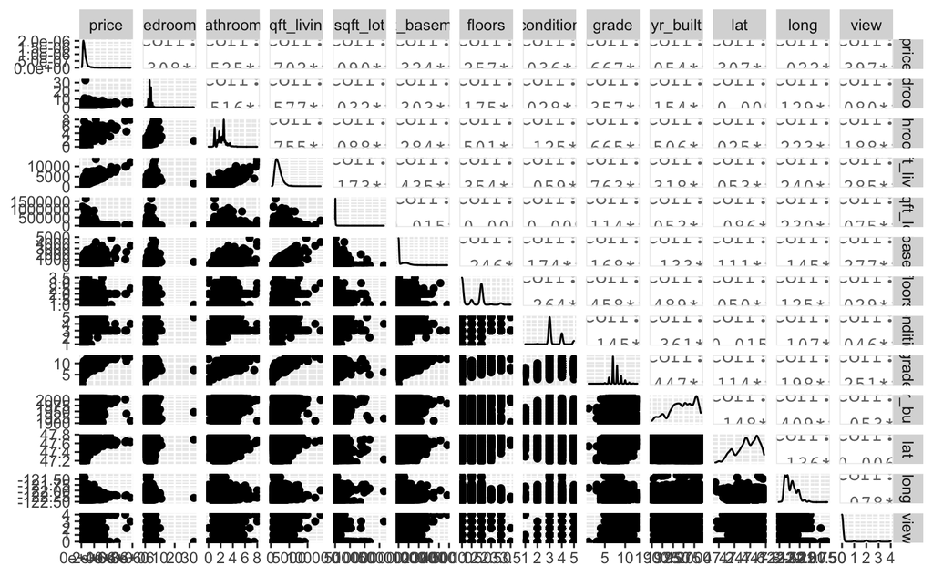

```r
houses_numeric <- houses %>%
  select(price, bedrooms, bathrooms, sqft_living, sqft_lot, sqft_basement,
         floors, condition, grade, yr_built, lat, long, view)

ggpairs(houses_numeric)
```

```r
houses_nonnumeric <- houses_clean %>%
  select_if(function(x) !is.numeric(x))

houses_nonnumeric
```

| waterfront | yr_renovated |
| --- | --- |
| FALSE | FALSE |
| FALSE | TRUE |
| FALSE | FALSE |
| FALSE | FALSE |
| FALSE | FALSE |
| FALSE | FALSE |
| FALSE | FALSE |
| FALSE | FALSE |
| FALSE | FALSE |
| FALSE | FALSE |

[output cut: 990 more lines]

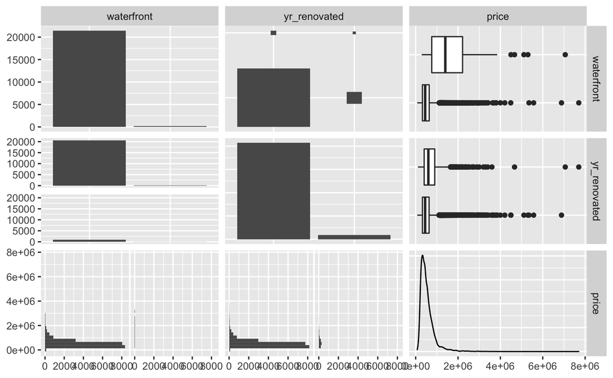

```r
houses_nonnumeric$price <- houses_clean$price

ggpairs(houses_nonnumeric)
```

Square foot of the living space - price increases by 280 for each increase in square foot. It accounts for 49% of variance in price.

```r
model_1 <- lm(price ~ sqft_living, data = houses)

summary(model_1)
```

```
Call:
lm(formula = price ~ sqft_living, data = houses)

Residuals:
     Min       1Q   Median       3Q      Max
-1476062  -147486   -24043   106182  4362067

Coefficients:
              Estimate Std. Error t value Pr(>|t|)
(Intercept) -43580.743   4402.690  -9.899   <2e-16 ***
sqft_living    280.624      1.936 144.920   <2e-16 ***
---
Signif. codes:  0 ‘***’ 0.001 ‘**’ 0.01 ‘*’ 0.05 ‘.’ 0.1 ‘ ’ 1

Residual standard error: 261500 on 21611 degrees of freedom
Multiple R-squared:  0.4929,    Adjusted R-squared:  0.4928
F-statistic: 2.1e+04 on 1 and 21611 DF,  p-value: < 2.2e-16
```

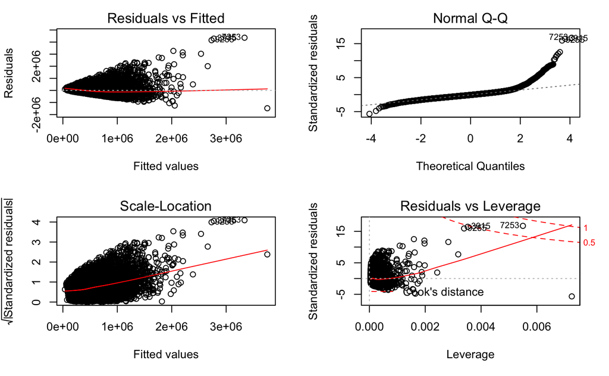

```r
par(mfrow = c(2, 2))

plot(model_1)
```

Searching for the predictors not yet in our model by adding the residuals.

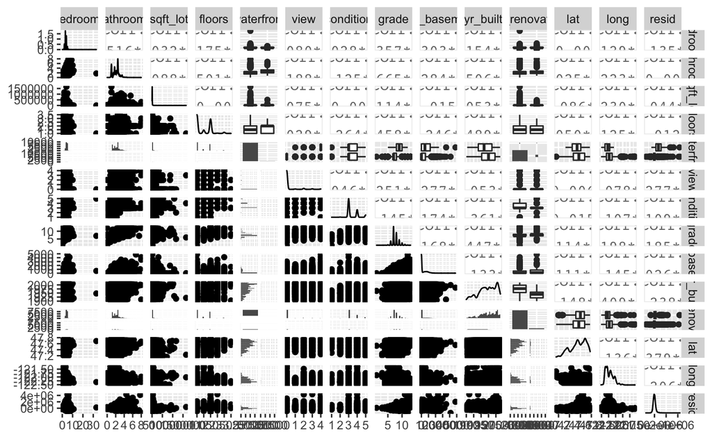

```r
remaining_residuals <- houses %>%
  add_residuals(model_1) %>%
  select(-c("price", "sqft_living"))

remaining_residuals %>%
  ggpairs()
```

```r
model_2 <- lm(price ~ sqft_living + yr_built, data = houses)

summary(model_2)
```

```
Call:
lm(formula = price ~ sqft_living + yr_built, data = houses)

Residuals:
     Min       1Q   Median       3Q      Max
-1684544  -137797   -20753   105703  4036827

Coefficients:
              Estimate Std. Error t value Pr(>|t|)
(Intercept)  4.546e+06  1.206e+05   37.69   <2e-16 ***
sqft_living  3.046e+02  1.977e+00  154.03   <2e-16 ***
yr_built    -2.354e+03  6.183e+01  -38.07   <2e-16 ***
---
Signif. codes:  0 ‘***’ 0.001 ‘**’ 0.01 ‘*’ 0.05 ‘.’ 0.1 ‘ ’ 1

Residual standard error: 253100 on 21610 degrees of freedom
Multiple R-squared:  0.5247,    Adjusted R-squared:  0.5247
F-statistic: 1.193e+04 on 2 and 21610 DF,  p-value: < 2.2e-16
```

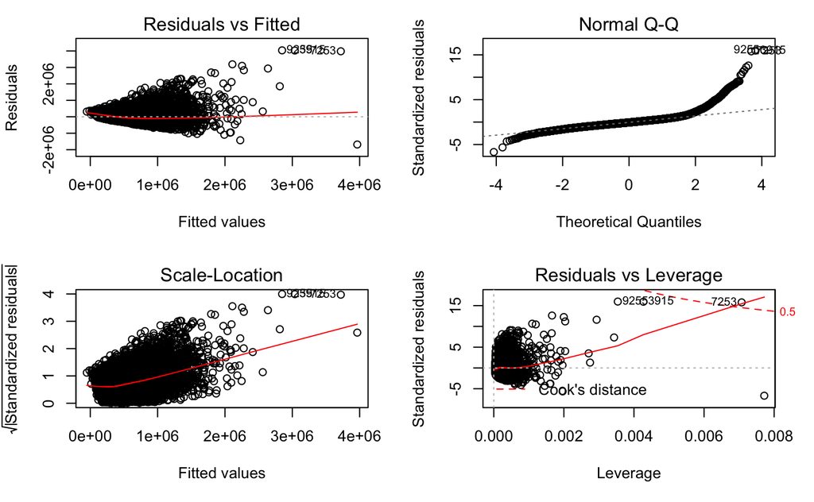

```r
par(mfrow = c(2, 2))

plot(model_2)
```

There is a statistically significant difference if the model includes year built so that can be kept in the model.

```r
anova(model_1, model_2)
```

```
Analysis of Variance Table

Model 1: price ~ sqft_living
Model 2: price ~ sqft_living + yr_built
  Res.Df        RSS Df  Sum of Sq      F    Pr(>F)
1  21611 1.4773e+15
2  21610 1.3844e+15  1 9.2854e+13 1449.4 < 2.2e-16 ***
---
Signif. codes:  0 ‘***’ 0.001 ‘**’ 0.01 ‘*’ 0.05 ‘.’ 0.1 ‘ ’ 1
```

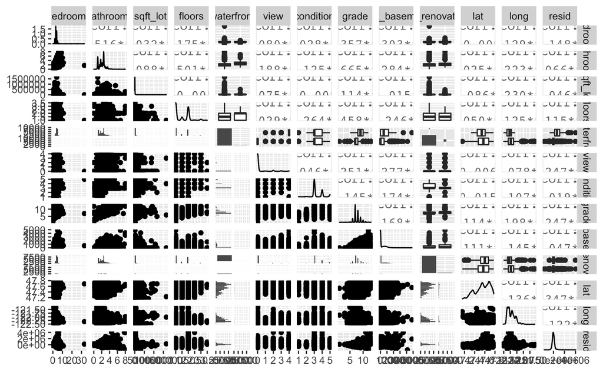

```r
remaining_residuals2 <- houses %>%
  add_residuals(model_2) %>%
  select(-c("price", "sqft_living", "yr_built"))

remaining_residuals2 %>%
  ggpairs()
```

Visualising the interaction between view and waterfront.

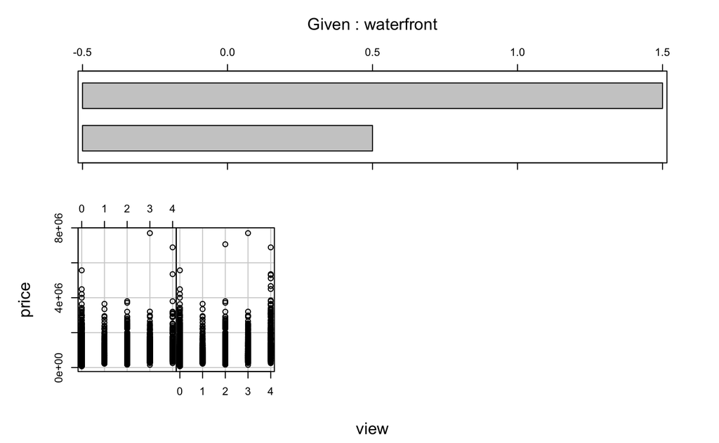

```r
coplot(price ~ view | waterfront, data = houses, columns=6)
```

```r
model_3 <- lm(price ~ sqft_living + yr_built + view:waterfront, data = houses)

summary(model_3)
```

```
Call:
lm(formula = price ~ sqft_living + yr_built + view:waterfront,
    data = houses)

Residuals:
     Min       1Q   Median       3Q      Max
-1649345  -130394   -16426   106467  4076019

Coefficients:
                       Estimate Std. Error t value Pr(>|t|)
(Intercept)           3.836e+06  1.158e+05   33.13   <2e-16 ***
sqft_living           2.798e+02  1.979e+00  141.37   <2e-16 ***
yr_built             -1.977e+03  5.940e+01  -33.29   <2e-16 ***
view:waterfrontFALSE  6.450e+04  2.447e+03   26.36   <2e-16 ***
view:waterfrontTRUE   2.152e+05  5.003e+03   43.01   <2e-16 ***
---
Signif. codes:  0 ‘***’ 0.001 ‘**’ 0.01 ‘*’ 0.05 ‘.’ 0.1 ‘ ’ 1

Residual standard error: 240100 on 21608 degrees of freedom
Multiple R-squared:  0.5724,    Adjusted R-squared:  0.5723
F-statistic:  7231 on 4 and 21608 DF,  p-value: < 2.2e-16
```

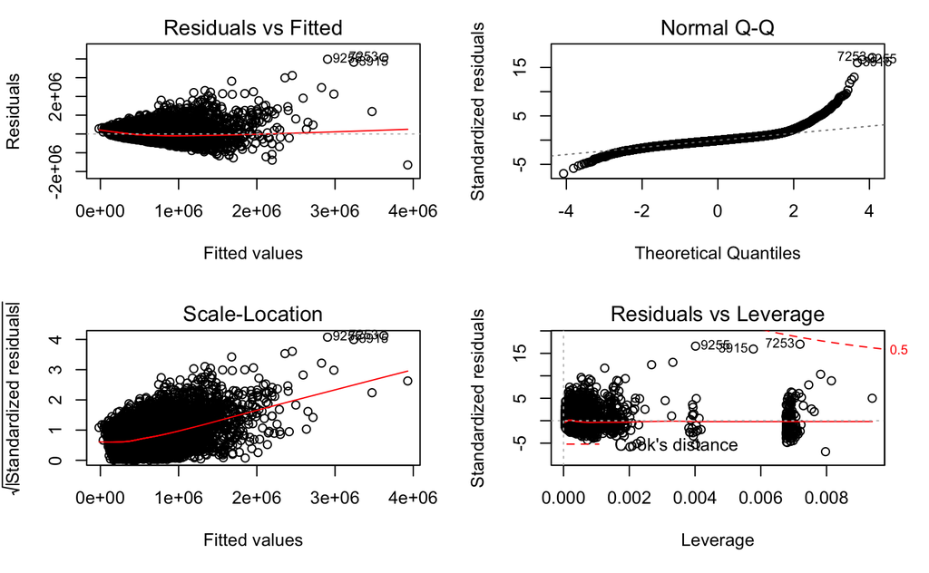

```r
par(mfrow = c(2, 2))

plot(model_3)
```

```r
anova(model_2, model_3)
```

```
Analysis of Variance Table

Model 1: price ~ sqft_living + yr_built
Model 2: price ~ sqft_living + yr_built + view:waterfront
  Res.Df        RSS Df  Sum of Sq      F    Pr(>F)
1  21610 1.3844e+15
2  21608 1.2456e+15  2 1.3884e+14 1204.3 < 2.2e-16 ***
---
Signif. codes:  0 ‘***’ 0.001 ‘**’ 0.01 ‘*’ 0.05 ‘.’ 0.1 ‘ ’ 1
```

```r
library(relaimpo)
```

```r
calc.relimp(model_3, type = "lmg", rela = TRUE)
```

```
Error in WW2$WW[i, 2] : subscript out of bounds
```

```r
library(lm.beta)

model_3_betas <- lm.beta(model_3)
summary(model_3)
```

```
Call:
lm(formula = price ~ sqft_living + yr_built + view:waterfront,
    data = houses)

Residuals:
     Min       1Q   Median       3Q      Max
-1649345  -130394   -16426   106467  4076019

Coefficients:
                       Estimate Std. Error t value Pr(>|t|)
(Intercept)           3.836e+06  1.158e+05   33.13   <2e-16 ***
sqft_living           2.798e+02  1.979e+00  141.37   <2e-16 ***
yr_built             -1.977e+03  5.940e+01  -33.29   <2e-16 ***
view:waterfrontFALSE  6.450e+04  2.447e+03   26.36   <2e-16 ***
view:waterfrontTRUE   2.152e+05  5.003e+03   43.01   <2e-16 ***
---
Signif. codes:  0 ‘***’ 0.001 ‘**’ 0.01 ‘*’ 0.05 ‘.’ 0.1 ‘ ’ 1

Residual standard error: 240100 on 21608 degrees of freedom
Multiple R-squared:  0.5724,    Adjusted R-squared:  0.5723
F-statistic:  7231 on 4 and 21608 DF,  p-value: < 2.2e-16
```